Skip to contents

# 🚀 快速入门

Source: [`vignettes/articles/zh/get-started.Rmd`](https://github.com/Linbojun99/faofishingreport/blob/main/vignettes/articles/zh/get-started.Rmd)

```r
fao_settings(lang = "zh")   # 本文所有图表使用中文
```

📦 **数据来源**：[FAO全球捕捞产量](https://www.fao.org/fishery/collection/capture/en)（Global Capture Production）**2026.1.0**版（FAO于2026-03-30发布，1950–2024年），下载地址Capture_2026.1.0.zip，许可证[CC BY 4.0](https://creativecommons.org/licenses/by/4.0/)。用`fao_data_info()`查看你使用的版本和引用格式。

**faofishingreport**把FAO全球捕捞产量统计（Global Capture Production）整理成报告用的图表、地图和表格。 本文以**东北大西洋（FAO主要渔区27）**为例，完整演示第一次分析的全过程；下面每张图都由其上方的代码生成。

典型的工作流程：

| 步骤 | 做什么 | 函数 |
| --- | --- | --- |
| 1. 数据 | 检查并下载FAO最新版本，查看所用的版本 | `check_fao_update()`、`download_fao_data()`、`fao_data_info()` |
| 2. 渔区 | 某个渔区的总产量、主要物种和主要捕捞国家 | `fishing_area_data()`、`fishing_area_species()`、`fishing_area_country()` |
| 3. 物种与国家 | 某个物种由哪些国家捕捞，某个国家捕什么 | `species_country()`、`country_species()`、`country_analysis()` |
| 4. 汇总分析 | 类群结构、资源开发状态、趋势、数据质量、多样性、船队 | `species_group_composition()`、`stock_status()`、`peak_trend()`、`data_quality()`、`coastal_distant()`等 |
| 5. 文献方法 | 渔获骤变、渔业崩溃、同步性、中上层/底层比、渔获平均温度 | `catch_shocks()`、`collapse_analysis()`、`catch_synchrony()`、`pelagic_demersal()`、`mean_temperature_catch()` |
| 6. 资源评估 | 主要物种的CMSY++评估 | `cmsy_setup()`、`cmsy_area()` |
| 7. 报告 | 一键生成某个渔区的Word报告 | `fao_report()` |
| 8. 风格 | 语言、主题、颜色、地图投影 | `fao_settings()` |

## 📦 安装

faofishingreport需要**R 4.2或以上版本**，从GitHub安装：

```r
install.packages("remotes")
remotes::install_github("Linbojun99/faofishingreport", dependencies = TRUE)
```

设置`dependencies = TRUE`后，各项分析用到的包都会随本包一起安装：绘制图表和地图的dplyr、ggplot2和sf，提供世界地图的rnaturalearth，生成Word报告的officer和xml2，输出可编辑PowerPoint图表的eoffice，读取FishBase和SeaLifeBase数据表的nanoparquet，读取海表温度文件的ncdf4，以及CMSY++所需的R包（coda、conicfit、gplots、MASS、mvtnorm、neuralnet等）。唯一的例外是rjags和R2jags，它们需要单独的JAGS程序：第一次使用CMSY++时运行`cmsy_setup()`，即可安装JAGS和这两个包（见📉 CMSY++资源评估）。

**Windows和macOS**安装的是二进制包，不需要编译器（Rtools）。在macOS上输出可编辑的PowerPoint图表还需要安装[XQuartz](https://www.xquartz.org)。 **Linux**需要先安装sf包依赖的系统库；如果要绘制中文图表，还需要安装中文字体：

```bash
sudo apt-get install libgdal-dev libgeos-dev libproj-dev libudunits2-dev fonts-noto-cjk
```

加载本包。启动信息会显示当前操作系统和图表所用的字体（Windows上为SimSun，macOS上为Songti SC，Linux上为Noto Serif CJK SC）：

```r
library(faofishingreport)
```

## 💾 获取FAO最新数据

本包自带FAO 2026.1.0版本的数据。FAO大约每年发布一次新版本。可以先检查是否有更新的版本，再下载（约5 MB，几秒钟即可完成）：

```r
check_fao_update()
```

```
#> FAO Global Capture Production
#>   Latest online release: 2026.1.0 (published 2026-03-30)
#>   Bundled with package:  2026.1.0
#>   Downloaded locally:    none
#>   Your data is up to date.
```

```r
download_fao_data()   # 只有在有更新版本时才需要运行
```

所有函数都会自动使用可用的最新数据。`fao_data_info()`显示所用的是哪个版本、来自哪里以及如何引用。这些函数的全部参数、如何选择版本、数据格式以及如何分析自己的数据子集，见💾 FAO数据。

## 📁 结果保存在哪里

每项分析都会把图表和表格保存在**当前工作目录**中：

| 文件夹 | 内容 |
| --- | --- |
| `figures/png/` | PNG格式的图表（始终输出）；汇总分析的图表在`figures/png/summary/` |
| `figures/pptx/` | 可编辑的PowerPoint图表（设置`pptx = TRUE`时输出，使用eoffice包） |
| `tables/` | CSV格式的表格，用Excel打开时中文名称也能正常显示 |
| `reports/` | `fao_report()`生成的Word报告 |

所以先为报告选定一个文件夹：

```r
setwd("D:/reports/FAO27")   # 任意文件夹均可
```

## 🌊 第一次分析：FAO 27渔区

`fishing_area_data()`提取某个FAO主要渔区的产量数据，绘制该渔区的总产量并标出平均产量的突变点，计算其占全球所有海洋渔区捕捞产量的比例，并绘制在该渔区捕捞的国家的世界地图。

```r
FAO27 <- fishing_area_data("Atlantic, Northeast")
```

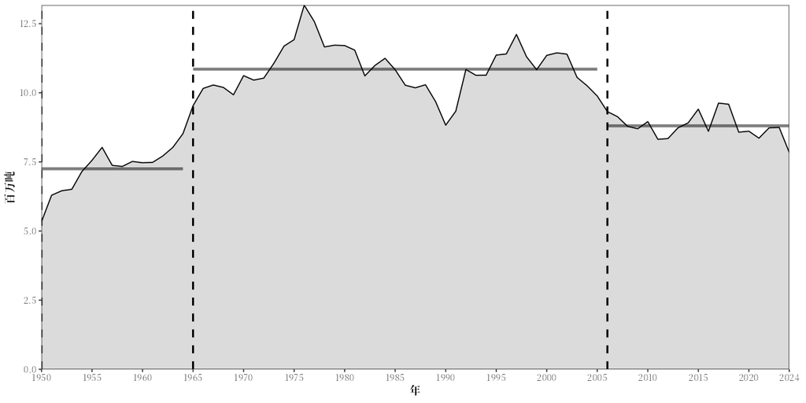

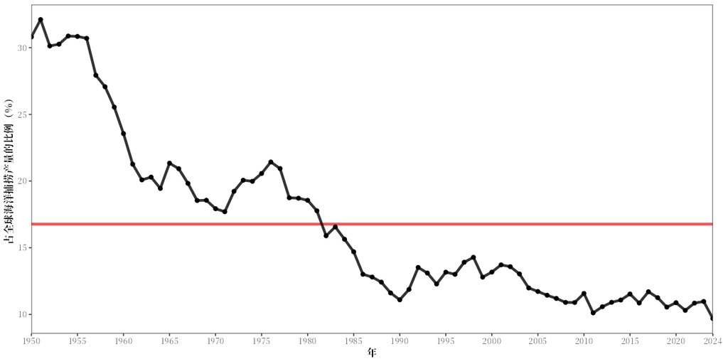

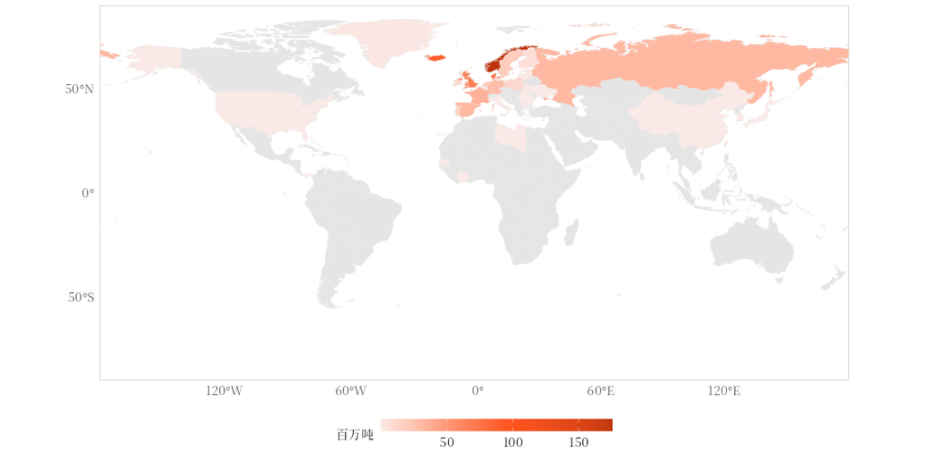

返回结果是一个列表，包括该渔区的产量记录（`area_data`）、相邻突变点之间的各个时段（`coefs_data`）和地图数据（`act_world_map`）。其中`FAO27$area_data`是其他大多数函数的输入数据：

```r
show_table(FAO27$area_data, n = 5)
```

|  | Country..Name. | ASFIS.species..Name. | FAO.major.fishing.area..Name. | Unit..Name. | Unit | Year | Production | Production.Type |
| --- | --- | --- | --- | --- | --- | --- | --- | --- |
| 51634 | Belgium | European eel | Atlantic, Northeast | Tonnes - live weight | TLW, Number | 2018 | 1.0 | actual |
| 51635 | Belgium | European eel | Atlantic, Northeast | Tonnes - live weight | TLW, Number | 2019 | 1.0 | actual |
| 51636 | Belgium | European eel | Atlantic, Northeast | Tonnes - live weight | TLW, Number | 2020 | 0.7 | actual |
| 51637 | Belgium | European eel | Atlantic, Northeast | Tonnes - live weight | TLW, Number | 2021 | 1.0 | actual |
| 51638 | Belgium | European eel | Atlantic, Northeast | Tonnes - live weight | TLW, Number | 2022 | 0.0 | actual |

其他渔区的用法完全相同。全部FAO主要渔区的名称如下：

```r
data <- load_fao_data()
sort(unique(data$FAO.major.fishing.area..Name.))
```

```
#>  [1] "Africa - Inland waters"           "America, North - Inland waters"
#>  [3] "America, South - Inland waters"   "Arctic Sea"
#>  [5] "Asia - Inland waters"             "Atlantic, Antarctic"
#>  [7] "Atlantic, Eastern Central"        "Atlantic, Northeast"
#>  [9] "Atlantic, Northwest"              "Atlantic, Southeast"
#> [11] "Atlantic, Southwest"              "Atlantic, Western Central"
#> [13] "Europe - Inland waters"           "Former USSR area - Inland waters"
#> [15] "Indian Ocean, Antarctic"          "Indian Ocean, Eastern"
#> [17] "Indian Ocean, Western"            "Mediterranean and Black Sea"
#> [19] "Oceania - Inland waters"          "Pacific, Antarctic"
#> [21] "Pacific, Eastern Central"         "Pacific, Northeast"
#> [23] "Pacific, Northwest"               "Pacific, Southeast"
#> [25] "Pacific, Southwest"               "Pacific, Western Central"
```

## 🐟 主要物种和国家

27渔区产量最高的十个物种、它们的产量变化以及平均产量的突变点：

```r
species <- fishing_area_species(FAO27$area_data, rank_range = 1:10)
```

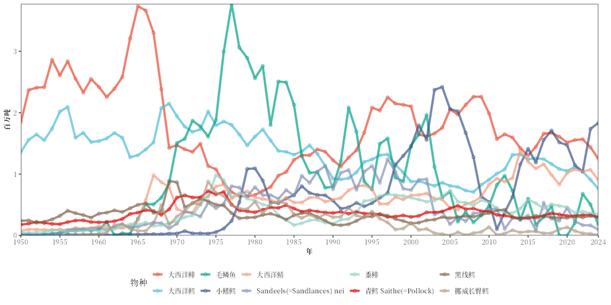

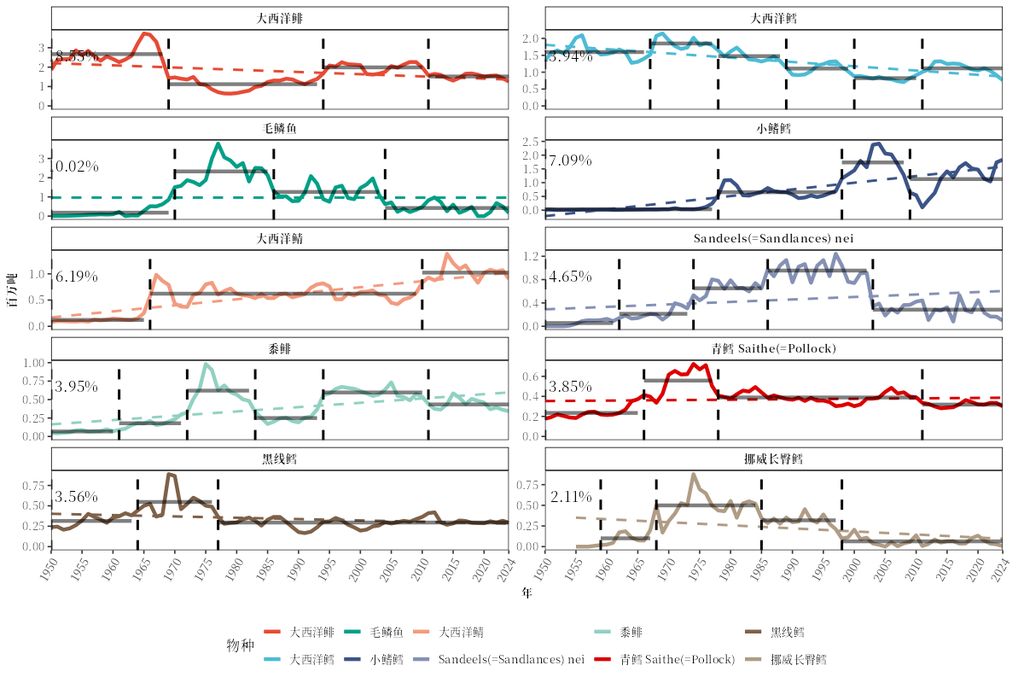

主要捕捞国家的分析方法相同：

```r
countries <- fishing_area_country(FAO27$area_data, rank_range = 1:10)
```

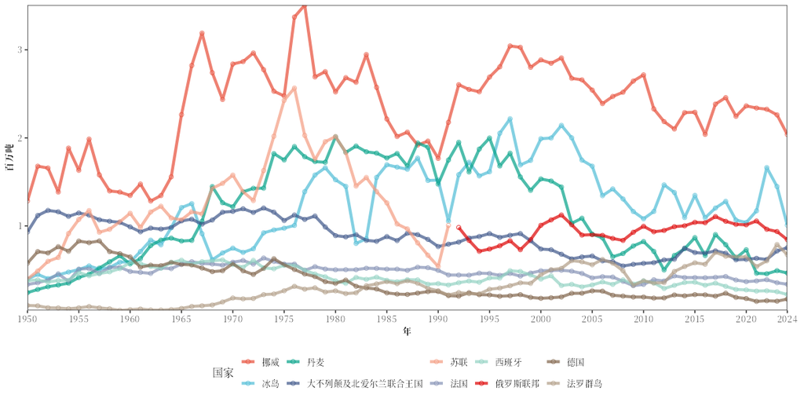

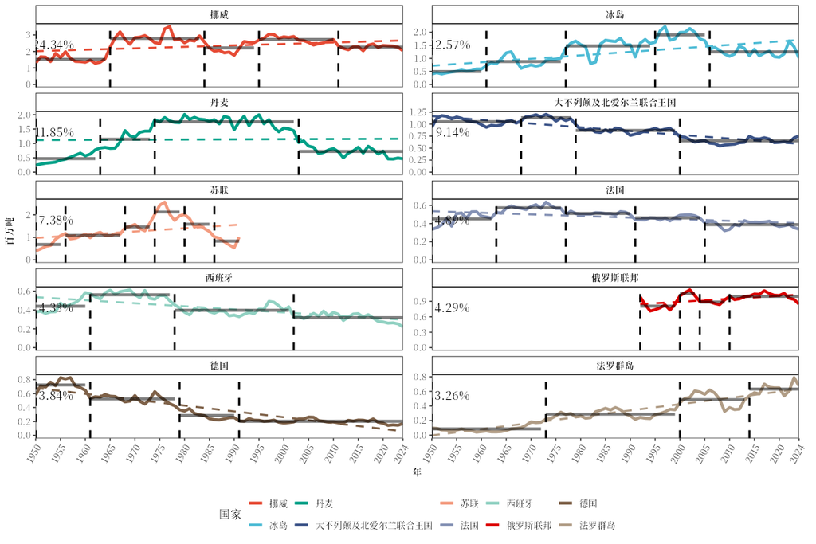

`rank_range`列出要显示的名次：`1:10`为前十名，`11:20`为其后十名，`c(5, 6)`为第五和第六名。

## 🖥️ 控制台中显示的结果

函数运行结束时，会在控制台显示结果摘要：分析的对象、主要结果表的前几行、保存的图表和表格，以及返回结果包含的部分。结果本身以不可见的方式返回，赋值（`species <- ...`）即可保存。下面是第五和第六名物种：

```r
fao_settings(show_data = TRUE)   # 默认设置（本网站的文章关闭了摘要）
species56 <- fishing_area_species(FAO27$area_data, rank_range = c(5, 6))
```

```
#>
#> ── fishing_area_species(): Atlantic, Northeast ─────────────────────────────────
#> Ranks 5 to 6 of 1029 species items, by catch over all years (catch_t and share_pct: all years):
#>  rank                   species    catch_t share_pct
#>     5 大西洋鲭                  44,615,940      6.19
#>     6 Sandeels(=Sandlances) nei 33,532,765      4.65
#> Charts saved in figures/png/area/: area_species.png, area_species_wrap.png
#> Tables saved in tables/: species_ranked_table.csv, species_coefs_data.csv
#> Results returned: $area_species, $area_species_ranked, $area_species_ranked_total, $coefs_data
```

```r
fao_settings(show_data = FALSE)
```

`plot_show = TRUE`会在保存每张图的同时，把图画在绘图窗口中（RStudio的Plots窗格）；无论是否显示，`plot = TRUE`都会保存图片文件：

```r
species <- fishing_area_species(FAO27$area_data, rank_range = 1:10, plot_show = TRUE)
fao_settings(plot_show = TRUE)    # 本次会话的所有函数都显示图
fao_settings(show_data = FALSE)   # 不在控制台显示摘要
```

## 🌐 中文与中英双语图表

每项分析都有一个`lang`参数，取值为`"en"`（英文）、`"zh"`（中文）或`"both"`（中英双语）。国家、物种和渔区名称使用FAO官方中文名。

```r
species_country(FAO27$area_data, species_name = "Atlantic cod", lang = "both")
```

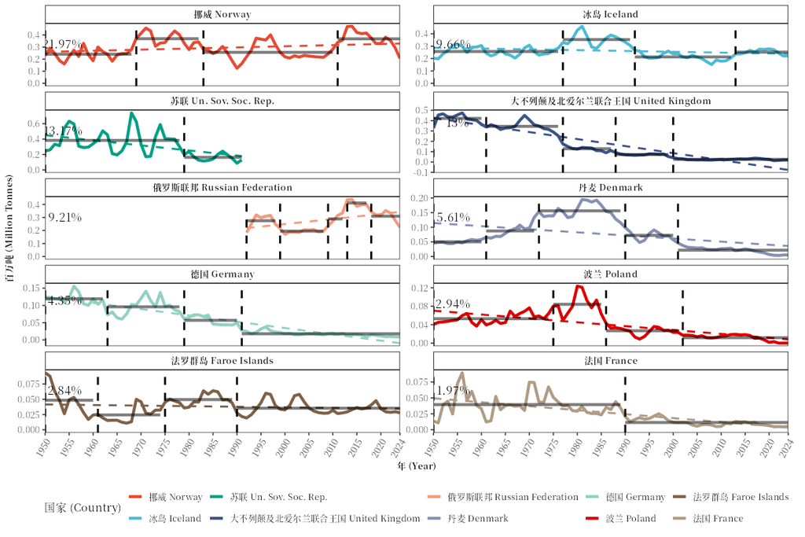

如果希望所有图表都使用中文，只需用`fao_settings(lang = "zh")`设置一次即可。本文开头就是这样设置的，所以本文其余的图表都是中文。

## 📊 第一项汇总分析：资源开发状态

`stock_status()`根据每个物种的产量相对于其历史峰值产量的比例，判断其资源开发状态（资源状态图，Kleisner等2013）：

```r
status <- stock_status(FAO27$area_data)
```

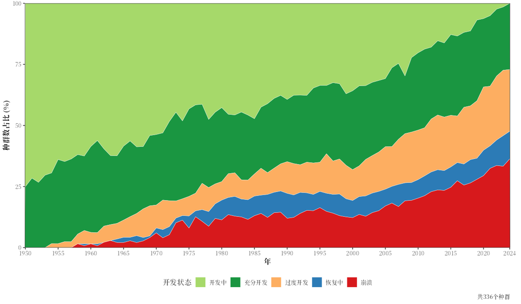

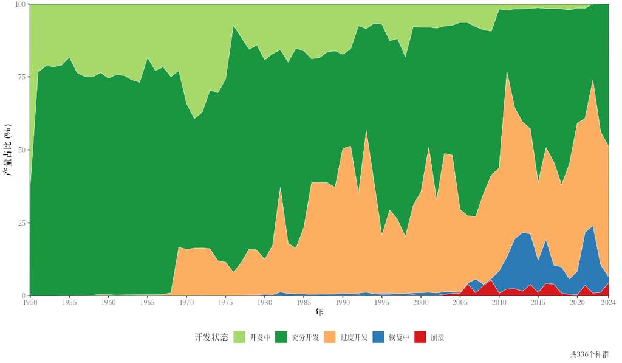

## 📝 一键生成Word报告

`fao_report()`运行某个渔区的各项分析，并生成一份Word报告，包括封面、摘要、数据来源与分析方法、附图表的结果、结论、参考文献和附表。渔区可以用名称或代码指定：

```r
fao_report(27, lang = "en")   # 在工作目录中生成reports/FAO27_report_en.docx
```

报告默认包括总产量及其阶段、主要物种和主要国家、ISSCAAP类群、资源状态图、数据质量、渔获多样性，以及沿岸国与远洋捕捞；渔获骤变、渔业崩溃、同步性、中上层/底层比、渔获平均温度、远洋国家概况和CMSY++可以另外打开。把`lang`设为`"zh"`即生成中文报告。全部设置见📝 一键生成评估报告（Word、LaTeX、PDF）。

## ⚙️ 本文所用函数的设置

各分析函数共有的参数：

| 参数 | 含义 | 默认值 |
| --- | --- | --- |
| `lang` | 图表文字和名称的语言：`"en"`、`"zh"`或`"both"` | `NULL`：使用`fao_settings()`中的语言（默认`"en"`） |
| `plot` | 是否保存图表 | `TRUE` |
| `table` | 是否在`tables/`中保存表格（`fishing_area_data()`没有此参数） | `TRUE` |
| `pptx` | 同时保存可编辑的PowerPoint图表 | `FALSE`，或`fao_settings()`中的`pptx` |
| `plot_show` | 保存图表的同时把图画在绘图窗口中（例如RStudio的Plots窗格） | `FALSE`，或`fao_settings()`中的`plot_show` |
| `ZH` | 指定中文的旧方式：`ZH = TRUE`等同于`lang = "zh"`（只有渔区、物种和国家分析函数有此参数） | `FALSE` |
| `label` | 汇总分析（如`stock_status()`）输出文件名中使用的名称 | `NULL`：数据所属的渔区（或国家） |

每个函数还有各自的参数，各篇文章中都有完整的参数表：

| 函数 | 主要参数 | 全部参数 |
| --- | --- | --- |
| `check_fao_update()`、`download_fao_data()`、`load_fao_data()`、`fao_data_info()` | `version`、`data_dir`、`overwrite`、`quiet` | 💾 FAO数据 |
| `fishing_area_data()` | `area_name`、`timeseries_analysis`、`data_version`、颜色和文字大小 | 🌊 渔区分析 |
| `fishing_area_species()`、`fishing_area_country()` | `rank_range`、`timeseries_analysis`、`h_value`、线条和文字样式 | 🌊 渔区分析 |
| `species_country()` | `species_name`、`rank_range`、`h_value`、地图样式 | 🐟 物种与国家分析 |
| `stock_status()` | `taxon_levels`、`min_years`、`min_consecutive`、`min_catch`、`smooth` | 📈 类群结构、资源状态与趋势 |
| `fao_report()` | `area`、`lang`、`file`、各部分的开关、各项分析的设置 | 📝 一键生成评估报告（Word、LaTeX、PDF） |
| `fao_settings()`、`fao_font()` | `lang`、`theme`、`palette`、`map_projection`、`dpi`等 | 🎨 自定义图表与地图 |

## 🧭 下一步

- 🎓 教程：东北太平洋（FAO 67区）从零到报告：一个完整的示例，涵盖本包的全部分析，并讲解每张图怎么看
- 💾 FAO数据：下载与自定义：版本、数据格式、数据子集、中文名称
- 🌊 渔区分析：渔区分析函数的全部选项
- 🐟 物种与国家分析：`species_country()`、`country_species()`、`country_analysis()`
- 📈 类群结构、资源状态与趋势和🔍 数据质量、多样性与船队：各项汇总分析
- 🔬 渔获骤变、渔业崩溃、同步性与远洋捕捞：来自文献的方法（渔获骤变、渔业崩溃、同步性与组合效应、远洋船队，以及FAO数据版本之间的修订）
- 🌡️ 海表温度与渔获平均温度：渔区海表温度（内置或读取自己的NetCDF文件）与渔获平均温度
- 🐠 FishBase与SeaLifeBase物种特征：将FAO物种条目与FishBase和SeaLifeBase匹配，并使用其物种特征
- 📉 CMSY++资源评估：主要物种的仅基于渔获量的资源评估
- 📝 一键生成评估报告（Word、LaTeX、PDF）：把某个渔区的全部分析写成一份Word报告
- 🧩 扩展（不纳入Word报告）：🚢 贸易与就业：进出口与渔获的对比、渔业与养殖从业人数、人均渔获
- 🎨 自定义图表与地图：主题、色板、地图投影、字体和输出设置

## 📖 参考文献

Bai, J. and Perron, P. (2003). Computation and analysis of multiple structural change models. *Journal of Applied Econometrics* 18(1): 1–22. [doi:10.1002/jae.659](https://doi.org/10.1002/jae.659)

CWP (Coordinating Working Party on Fishery Statistics). *CWP Handbook of Fishery Statistics*: Main water areas (FAO major fishing areas). Rome: FAO. https://www.fao.org/cwp-on-fishery-statistics/handbook/general-concepts/main-water-areas/en/

FAO (2026). FishStat: Global capture production 1950–2024 (release 2026.1.0). In: FishStatJ. https://www.fao.org/fishery/statistics/software/fishstatj/en. Licence: CC-BY-4.0. Release file: https://www.fao.org/fishery/static/Data/Capture_2026.1.0.zip

FAO (2026). *Fishery and Aquaculture Statistics – Yearbook 2024*. FAO Yearbook of Fishery and Aquaculture Statistics. Rome: FAO. [doi:10.4060/ce1217en](https://doi.org/10.4060/ce1217en)

Kleisner, K., Zeller, D., Froese, R. and Pauly, D. (2013). Using global catch data for inferences on the world’s marine fisheries. *Fish and Fisheries* 14(3): 293–311. [doi:10.1111/j.1467-2979.2012.00469.x](https://doi.org/10.1111/j.1467-2979.2012.00469.x)

Natural Earth. Free vector and raster map data at 1:10m, 1:50m and 1:110m scales. https://www.naturalearthdata.com/

Zeileis, A., Kleiber, C., Krämer, W. and Hornik, K. (2003). Testing and dating of structural changes in practice. *Computational Statistics & Data Analysis* 44(1–2): 109–123. doi:10.1016/S0167-9473(03)00030-6

Zeileis, A., Leisch, F., Hornik, K. and Kleiber, C. (2002). strucchange: an R package for testing for structural change in linear regression models. *Journal of Statistical Software* 7(2): 1–38. [doi:10.18637/jss.v007.i02](https://doi.org/10.18637/jss.v007.i02)